# Occurrence Maps

Author

Francisco Riaño

Published

November 2, 2026

## Proposed Design

- Prepare one reusable set of coordinate-valid records within the Neotropical boundary.
- Display geographic distribution as rasterized point panels separated by source group.
- Aggregate records into an equal-area hexagonal grid rather than plot 1.37 million overlapping points.
- Use the dissolved Neotropical boundary as the mask and outline.
- Use a logarithmic color scale for record counts.
- Retain empty areas so sampling gaps remain visible.
- Report the number of coordinate-valid records used and records outside the Neotropical boundary.
- Avoid exposing individual occurrence coordinates in the rendered output.

## Loading Data

The complete EpIG-DB 2.0 occurrence product is loaded locally. The raw database is employed only to prepare aggregate outputs and is not displayed in the HTML document.

## Spatial Data Preparation

### Spatial Layers

Three spatial inputs are prepared. the dissolved Neotropical boundary, country boundaries, and the Morrone biogeographic provinces. Invalid geometries are repaired before further spatial operations.

Table Table 1 documents the role, size, geometry status, and coordinate reference system of each spatial input. All three inputs use WGS84 (EPSG:4326).

Table 1: Spatial layers used in the occurrence-map workflow.

| Layer | Purpose | Features | Invalid geometries before repair | EPSG |
| --- | --- | --- | --- | --- |
| Neotropical boundary | Analysis mask and outer boundary | 2 | 0 | 4,326 |
| Countries | Political reference boundaries | 58 | 1 | 4,326 |
| Biogeographic provinces | Morrone biogeographic units for subsequent maps | 60 | 0 | 4,326 |

### Coordinate Screening

Longitude and latitude are converted to numeric values and evaluated sequentially. Records must have a complete coordinate pair, fall within the legal geographic ranges, and not represent the placeholder coordinate ‘(0, 0)’.

Table Table 2 shows how coordinate-valid subset was obtained. Exclusion categories are mutually exclusive within this sequence.

Table 2: Sequential screening of occurrence coordinates.

| Screening step | Records | Percentage of all records |
| --- | --- | --- |
| All occurrence records | 1,372,136 | 100.0% |
| Excluded: incomplete or non-numeric coordinate pair | 1,715 | 0.1% |
| Excluded: coordinate outside legal range | 0 | 0.0% |
| Excluded: placeholder coordinate (0, 0) | 0 | 0.0% |
| Retained: coordinate-valid records | 1,370,421 | 99.9% |

### Projected Neotropical Dataset

Coordinate-valid records are projected to Equal Earth (EPSG:8857), filtered by the dissolved Neotropical boundary, and assigned to a 100-km equal-area hexagonal grid. Employing an equal-are projection makes the grid cells spatially comparable across the study region.

## Geographic Distribution

### Distribution by Data Source

The geographic distribution of coordinate-valid records was compared among four broad source groups. Separate panels were used because repositories account for most records and would obscure less sources in a single overlaid map. All panels use the same projection and geographic extent. Literature records are displayed with larger, more opaque points to improve visibility. Point intensity should therefore not be compared directly among panels.

[figure not shown]

Figure 1: Geographic distribution of coordinate-valid EpIG-DB occurrence records within the Neotropical region, separated by source group.

## Sampling Density

### Spatial Aggregation

Records retained within the Neotropical boundary are assigned to a 100-km hexagonal grid in the Equal Earth Projection. Interior cells are spatially comparable; cells intersecting the outer boundary are clipped for display.

Table Table 3 reports the final map denominator and verifies that all records inside the study boundary were assigned to grid cells.

Table 3: Summary of records and grid cells used in the occurrence-density map.

| Metric | Value |
| --- | --- |
| Coordinate-valid records | 1,370,421 |
| Records inside the Neotropical boundary | 1,369,441 |
| Records outside the Neotropical boundary | 980 |
| Records assigned to grid cells | 1,369,441 |
| Occupied grid cells | 2,136 |
| Empty grid cells | 353 |
| Cell-assignment check | Passed |

### Sampling Density Map

Figure Figure 2 displays the number of records in each occupied cell. The logarithmic color transformation preserves differences across a highly differentiated count distribution. Light-grey cells represent sampled-area gaps with no retained occurrence records.

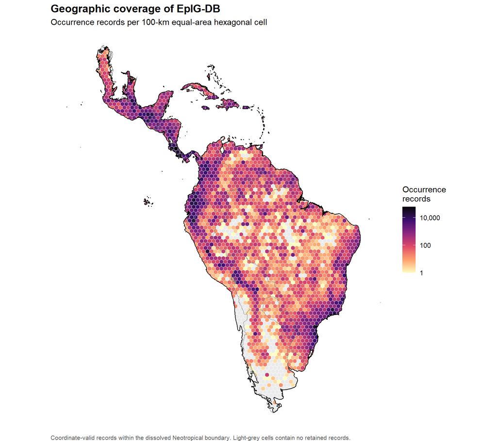

Figure 2: Spatial distribution of EpIG-DB occurrence records across the Neotropical region. Counts were aggregated within 100-km equal-area hexagonal cells: light-grey cells contain no retained records.

### Interpretation

The map summarizes geographic sampling intensity rather than species richness or biological abundance. Cells with many records may reflect greater collection effort, or repeated sampling. Consequently, geographic differences in record density should not be interpreted directly as differences in epiphyte diversity.

## Species Richness by Biogeographic Province

The province-level choropleth will represent the number of distinct formally named species recorded within each Morrone biogeographic province. Morphospecies will be evaluated separately because their identifiers may be contributor-specific.

The workflow is divided into:

1. audit the province layer and identify its province-name field;
2. define the records and taxonomic key used to count species;
3. assign eligible occurrences to province polygons;
4. validate unmatched and multiple spatial assignments;
5. calculate species richness while retaining provinces with zero records; and
6. construct and interpret the choropleth.

### Stage 1: Province Layer Audit

We must check for valid geometry, empty features, and overlapping province interiors.

Table Table 4 lists the available province attributes. The field selected as the province identifier should be complete and should normally contain one distinct value per province feature.

Table 4: Attributes available in the Morrone biogeographic-province layer.

| Attribute | Class | Non-missing features | Distinct non-missing values | Example values |
| --- | --- | --- | --- | --- |
| OBJECTID | numeric | 60 | 60 | 1; 2; 3 |
| Provincias | character | 57 | 57 | Araucaria Forest province; Atacama province; Atlantic province |
| IDProv | character | 0 | 0 |  |
| Region | character | 57 | 1 | Neotropical |
| Subregion | character | 57 | 5 | Chacoan; South American Transition Zone; Antillean |
| IDSubreg | character | 0 | 0 |  |
| Dominio | character | 38 | 7 | Parana; Mesoamerican; Chacoan |
| IDDominio | character | 0 | 0 |  |
| Area_km | character | 57 | 57 | 268459.892474321; 122518.721827285; 318663.938717835 |
| Perimetro | character | 57 | 57 | 7935.94906299966; 2231.80126228647; 14680.4424504175 |
| IDProvince | character | 0 | 0 |  |
| Shape_Leng | numeric | 60 | 60 | 67.5957607297; 18.928575915; 124.601108259 |
| Shape_Area | numeric | 60 | 60 | 19.5196932431; 9.20181450569; 24.1146207964 |

Table Table 5 reports the geometric conditions that could affect the subsequent point-in-polygon operation.

Table 5: Geometry audit of the Morrone biogeographic-province layer.

| Metric | Value |
| --- | --- |
| Province features | 60 |
| Geometry types after repair | MULTIPOLYGON |
| Empty geometries | 0 |
| Invalid geometries after repair | 0 |
| Source-layer EPSG | 4326 |
| Overlapping feature pairs | 4 |

### Stage 1b: Province-Layer Exceptions

The province layer contains 60 identified polygon features, but only 57 have province names. It also contains four pairs of overlapping interiors. these exceptions are examined before occurrences are assigned to provinces.

#### Display the unnamed features

Table 6: Province-layer features without a value in the Provincias field.

| province_row | OBJECTID | Provincias | Region | Subregion | Dominio | Area_km | Shape_Area |
| --- | --- | --- | --- | --- | --- | --- | --- |
| 58 | 349 | NA | NA | NA | NA | NA | 2.58e-05 |
| 59 | 364 | NA | NA | NA | NA | NA | 3.40e-05 |
| 60 | 376 | NA | NA | NA | NA | NA | 2.81e-05 |

#### Display the overlap pairs

Table 7: Pairs of biogeographic-province features with overlapping interiors.

| Province ID 1 | Province 1 | Province ID 2 | Province 2 | Overlap area (km²) | Smaller province area (km²) | Overlap share of smaller province |
| --- | --- | --- | --- | --- | --- | --- |
| 10 | Chaco province | 14 | Comechingones province | 0.01 | 7,386.6 | 0 |
| 10 | Chaco province | 19 | Esteros del Ibera province | 0.00 | 163,912.4 | 0 |
| 10 | Chaco province | 35 | Pampean province | 0.00 | 967,249.6 | 0 |
| 19 | Esteros del Ibera province | 35 | Pampean province | 0.00 | 163,912.4 | 0 |

### Stage 1c: Check Occurrences Matches

`st_intersects()` returns the polygon row numbers matching each point, including boundary contacts. A point on a shared boundary may therefore match more than one province.

Table 8: Province matches for coordinate-valid occurrence records within the Neotropical boundary

| Status | Records | Percentage |
| --- | --- | --- |
| One named province only | 1,369,441 | 100.00% |
| One named province plus unnamed feature(s) | 0 | 0.00% |
| Multiple named provinces | 0 | 0.00% |
| Unnamed feature(s) only | 0 | 0.00% |
| No province match | 0 | 0.00% |

### Stage 2: Define Records for Species Richness

Formally named species richness will be calculated from distinct cleaned `scientificName` values. Species, subspecies, varieties, and forms are included, following the species-level name structure established in the taxonomy audit (**Section 3.2** from `ExploratoryData_FR.qmd`). Morphospecies and hybrids are reported separately from this count.

**Note**: Observed species richness was calculated as the number of distinct cleaned `scientificName` values within each province. Eligible records included those ranked as species, subspecies, variety, or form, provided that a species name was present. Inspection of name mappings indicated that `scientificName` expresses infra-specific records at species level; screening found no values containing more than two words among these ranks. Consequently, records with the same species name were counted once per province, regardless of their recorded rank. We retained `scientificName` because `matchNameEpig` preserved some infra-specific names and was missing for 99,992 species-ranked records in the full database. Names were standardized by trimming and deleting any blank space and converting to lower case.

Table 9: Taxonomic composition of occurrence records with a unique named-province match.

| Taxonomic group | Records | Percentage |
| --- | --- | --- |
| Formally named species-level records | 1,360,944 | 99.38% |
| Morphospecies records | 8,483 | 0.62% |
| Hybrid records | 14 | 0.00% |

### Stage 3: Calculate Species Richness by Province

Table 10: Observed formally named species by Morrone biogeographic province.

| Province | Formally named occurrence records | Species richness |
| --- | --- | --- |
| Paramo province | 113,908 | 5,374 |
| Cauca province | 95,311 | 4,438 |
| Guatuso-Talamanca province | 163,177 | 3,345 |
| Yungas province | 82,999 | 2,910 |
| Puntarenas-Chiriqui province | 60,277 | 2,641 |
| Magdalena province | 30,566 | 2,577 |
| Atlantic province | 136,736 | 2,523 |
| Rondonia province | 20,411 | 1,797 |
| Choco-Darien province | 22,456 | 1,786 |
| Parana Forest province | 64,693 | 1,739 |
| Chiapas Highlands province | 61,928 | 1,711 |
| Ucayali province | 12,832 | 1,706 |
| Veracruzan province | 83,992 | 1,642 |
| Pacific Lowlands province | 34,621 | 1,619 |
| Napo province | 25,279 | 1,452 |
| Western Ecuador province | 14,999 | 1,425 |
| Guianan province | 21,389 | 1,295 |
| Sabana province | 5,721 | 1,203 |
| Sierra Madre del Sur province | 16,987 | 1,066 |
| Cerrado province | 19,966 | 1,053 |
| Araucaria Forest province | 44,180 | 1,004 |
| Guajira province | 7,141 | 959 |
| Mosquito province | 13,969 | 958 |
| Imeri province | 14,410 | 953 |
| Xingu-Tapajos province | 10,008 | 935 |
| Puna province | 6,325 | 911 |
| Transmexican Volcanic Belt province | 27,062 | 899 |
| Guianan Lowlands province | 19,532 | 836 |
| Madeira province | 10,099 | 735 |
| Venezuelan province | 4,010 | 712 |
| Caatinga province | 12,129 | 632 |
| Southern Espinhaco province | 6,228 | 610 |
| Roraima province | 9,328 | 576 |
| Sierra Madre Oriental province | 12,066 | 568 |
| Hispaniola province | 7,346 | 537 |
| Balsas Basin province | 4,367 | 508 |
| Jamaica province | 5,454 | 483 |
| Cuban province | 7,538 | 451 |
| Pampean province | 4,823 | 434 |
| Chapada Diamantina province | 7,387 | 424 |
| Chaco province | 11,725 | 396 |
| Puerto Rico province | 4,584 | 353 |
| Trinidad province | 2,464 | 345 |
| Para province | 4,299 | 331 |
| Lesser Antilles province | 1,827 | 276 |
| Ecuadorian province | 544 | 249 |
| Yucatan Peninsula Province | 7,503 | 234 |
| Sierra Madre Occidental province | 1,622 | 174 |
| Desert province | 742 | 155 |
| Monte province | 738 | 131 |
| Esteros del Ibera province | 707 | 98 |
| Galapagos Islands province | 1,840 | 69 |
| Bahama province | 413 | 56 |
| Comechingones province | 77 | 17 |
| Cayman Islands province | 19 | 14 |
| Cuyan High Andean province | 45 | 14 |
| Atacama province | 145 | 6 |

### Stage 4: Species Richness Map

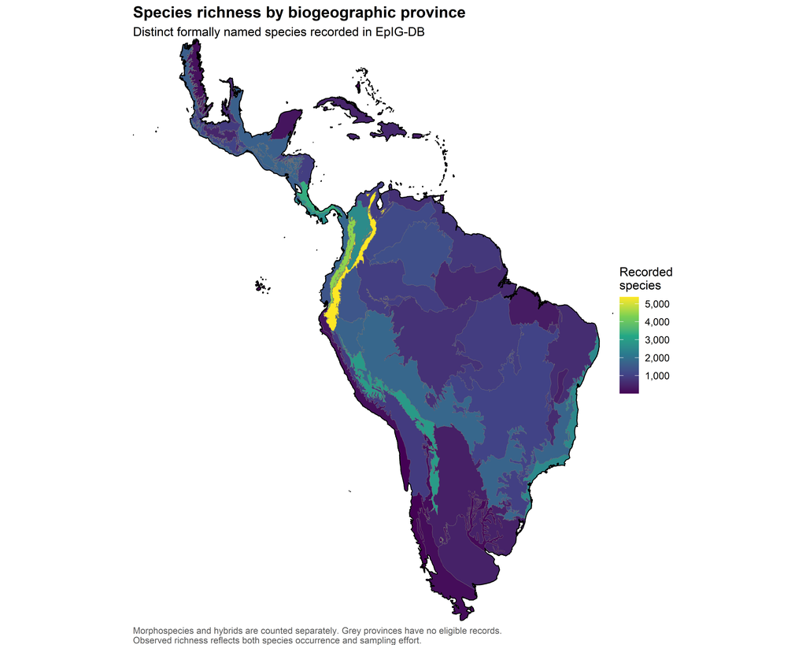

Figure 3: Observed formally named species richness across Morrone biogeographic provinces, based on coordinate-valid records within the Neotropical area.

### Stage 5: Species Richness per Existing 100-km Hexagonal Cell

We’ll start with **species richness per existing 100-km hexagonal cell**. The calculation is the same count each species once but the counting unit changes from a whole province to a grid cell.

| **Measure** | **What it describes** |
| --- | --- |
| Richness per province | Species recorded across the entire province. |
| Richness per hexagonal cell | Species recorded at a common spatial scale. |
| Rarefaction or coverage standardization | Diversity compared at a common sample size or sampling completeness; supported by iNEXT. |

**Grid-cell richness still dpeneds on collecting effort**. It supplements the province map; it is not a complete sampling correction. Also, cells clipped at the Neotropical boundary cover less area than interior cells.

#### 5.1: Species Richness at a Common Spatial Scale

Table 11: Occurrence counts and observed species richness among hexagonal cells containing eligible formally named records.

| Measure | Minimum | Median | Maximum |
| --- | --- | --- | --- |
| Formally named occurrence records per cell | 1 | 58 | 62,704 |
| Observed species richness per cell | 1 | 25 | 2,343 |

Among the 2,136 cells containing eligible records, record counts from 1 to 62,704, with a median of 58. Observed species richness ranged from 1 to 2,343 species per occupied cell, with a median of 25. The grid provides a common spatial scale, although boundary cells cover smaller areas. Unequal collecting effort remains a limitation, and these results should not be interpreted as sampling-standardized estimates of richness.

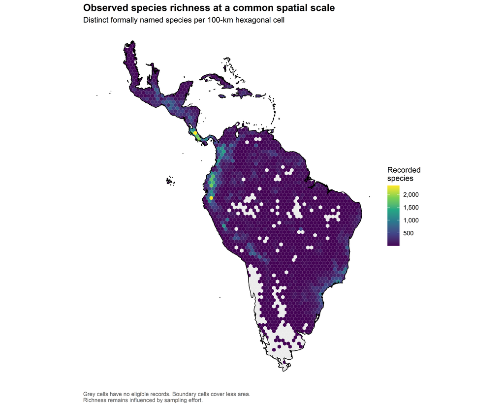

Figure 4: Observed formally named species richness within the existing 100-km equal-area hexagonal grid. Boundary cells are clipped to the Neotropical region; grey cells have no eligible records.